# Marketing Analítico com IA

## Marketing Analítico com IA

[figure not shown]

Avaliações de aplicativos nas lojas

Habilidades com código, coleta de dados da web, estruturação de textos e painéis que se atualizam sozinhos

Julio Trecenti · terça-feira, 10 de novembro de 2026

## Quiz da aula

[figure not shown]

Aponte a câmera para o QR e escolha um apelido. Uma pergunta no fim de cada parte da aula, sobre o que acabou de ser mostrado. Cada acerto vale de 1.000 pontos (resposta na hora) a 500 (no último segundo). Quem somar mais leva o prêmio.

## Aplicativos analisados

O exemplo da aula: o que os clientes escrevem sobre **sete aplicativos**, quatro bancos e três de delivery, na App Store e na Google Play.

Em cada cartão, a nota que a loja mostra na página e quantas notas ela soma. São milhões de clientes, e milhares de avaliações escritas por semana.

A pergunta de negócio: **do que os clientes reclamam, em cada app, e isso melhora ou piora?** Para responder, vamos baixar os textos, transformá-los em colunas e montar um painel que se atualiza todo dia. Trocar de app é mudar uma linha de uma planilha.

## Habilidades com código

Parte 1. Quando a IA precisa contar, somar ou baixar dados, a resposta tem de sair igual toda vez.

## Demonstração 1: contar menções num grupo focal

Demonstração 1 ChatGPT para computador, modo Work pasta demos/1-contagem

A entrevista está em `entrevista/grupo_focal_aerea_sol.txt`, uma fala por linha (`NOME: texto`). A habilidade `contar-termos` já está instalada.

## Contagens com e sem habilidade

O que deu na preparação do curso de executivos, com a transcrição original. A de hoje é a mesma conversa, com erros de digitação, sem acentos e mais jeitos de falar de preço: os números mudam, a lição não.

**Sem habilidade**, três conversas, três totais. O modelo escreve uma palavra de cada vez e, a cada conversa, escolhe um critério diferente (incluiu reembolso, tirou reembolso, incluiu bagagem) e conta “de olho”. Qual está certo? Ninguém sabe.

**Com a habilidade**, o modelo não conta: ele roda um **script** que segue uma lista de termos escrita. Dá 162 toda vez. E erra sempre igual (“filmando na **cara**” entra como preço), mas o erro aparece nos trechos, e corrigir a lista vale para sempre.

## Estrutura da habilidade contar-termos

A habilidade da demonstração é uma **pasta** com um texto de instruções, o `SKILL.md`, e um script.

**Nome e descrição:** é por eles que o ChatGPT reconhece que um pedido de contagem é com ela.

**Passo a passo e regras:** mostrar a lista de termos antes de contar, nunca contar de cabeça, e devolver a tabela do script sem mudar nenhum número.

**O script** faz a conta: procura cada termo como palavra inteira, fala por fala, e guarda cada ocorrência com o trecho, para conferir.

Ela poderia ter **arquivos de apoio**, como listas de termos de outros projetos. Esta não tem: só o texto e o script.

Na prática: o pedido chega, a descrição escolhe a habilidade, o `SKILL.md` guia e o script conta. O modelo volta no fim, para **interpretar**: quem fala mais de preço, e que trechos foram contados por engano.

## Pergunta 1

## Coleta de dados da web

Parte 2. Com uma habilidade pronta, baixar é um pedido. O cuidado passa a ser outro: o que esses dados mostram, e o que não mostram.

## Estrutura de uma habilidade

Uma habilidade é uma **pasta**. A única peça obrigatória é o `SKILL.md`, um texto com instruções.

No alto do `SKILL.md`, o **nome e a descrição**. É só isso que o ChatGPT lê para decidir se a habilidade serve para o seu pedido: escreva quando usar.

Depois, o **passo a passo** e as **regras**: o que fazer, em que ordem, e o que nunca fazer. O modelo lê e decide (qual app, o que perguntar).

Em `scripts/`, o **código** que executa: baixa, conta, junta. O computador roda, sempre igual. É o que torna a habilidade determinística.

E quantos **arquivos de apoio** forem úteis: documentação, exemplos, modelos de relatório, listas de termos. O modelo só os abre quando precisa.

Na prática: o pedido chega, a descrição escolhe a habilidade, o `SKILL.md` guia, o script executa. A habilidade completa está em `skills/avaliacoes-lojas/`.

## Demonstração 2: baixar as avaliações dos bancos

Demonstração 2 ChatGPT para computador, modo Work conversa nova, com a habilidade avaliacoes-lojas instalada

A App Store tem um feed público, feito para programas lerem: só as 500 avaliações mais recentes. A Google Play não tem: o pacote faz os mesmos pedidos que a página faz, e as 500 mais recentes cobrem só dois a quatro dias num app grande.

## Demonstração 3 (opcional): criar uma habilidade com o skill creator

Demonstração 3, se der tempo ChatGPT para computador, modo Work conversa nova

## Nota da loja e nota das avaliações escritas

O círculo vazio é a nota que a página da loja mostra: a média de milhões de notas, a maioria sem texto.

O ponto vermelho é a média das avaliações **escritas** dos últimos 30 dias, as que baixamos. Por que ele fica sempre à esquerda?

## Pergunta 2

## Estruturação de textos

Parte 3. Ninguém lê milhares de avaliações por semana. Mas dá para fazer as mesmas perguntas a cada uma, e transformar as respostas em colunas.

## Avaliação como linha de tabela

Uma avaliação real, como chegou da loja: 5 estrelas, mas reclamando.

Fazemos **as mesmas perguntas** a todas as avaliações: qual o tema principal? Ela reclama de algo?

As respostas viram colunas. Com colunas, dá para contar, comparar apps e acompanhar no tempo, como qualquer outra variável.

Cada resposta vem com a **confiança** do modelo. As de confiança baixa são as que valem a pena ler.

## Dicionário de variáveis

```
{"_instrucoes": "Você lê avaliações de aplicativos escritas
   por clientes na App Store ou na Play Store do Brasil.
   Responda a cada pergunta só com base no título e no
   texto da avaliação.",
 "variaveis": {
  "tema": {
   "pergunta": "Qual é o assunto principal da avaliação?",
   "tipo": "escolha",
   "opcoes": {
    "atraso na entrega": "o pedido demorou, atrasou ou nunca
       chegou, rastreamento errado",
    "cupons e promoções": "cupons, descontos, clube de
       assinatura, promoções que não funcionam", ...
    "elogio geral": "a avaliação elogia o app ou a empresa
       sem apontar um problema",
    "outro": "nenhuma das opções acima"}},
  "reclamacao": {
   "pergunta": "A avaliação reclama de alguma coisa (um
      problema, uma falha ou uma insatisfação)?",
   "tipo": "sim_nao"}}}
```

O **dicionário** é um arquivo (JSON) com as perguntas que vamos fazer a cada avaliação. Ele fica na pasta, e não solto na conversa.

**As instruções gerais** valem para todas as perguntas: quem lê, de onde vêm os textos, e a regra de ouro: responder só com o que está escrito.

**Cada variável** tem uma pergunta e um tipo. Aqui, `escolha`: a resposta é uma opção de uma lista fechada. Sem lista, cada avaliação ganharia uma categoria nova.

**Cada opção tem uma definição.** É o que o modelo lê para decidir, como alguém novo na equipe leria um manual. No painel, bancos e delivery têm listas diferentes.

**Opções para o que não é problema** (“elogio geral”) e um **“outro”** para o que não cabe em nenhuma. Sem elas, o modelo força o texto numa opção errada.

**Uma segunda variável**, do tipo sim ou não: a avaliação reclama de algo? Cada variável vira uma coluna da tabela.

## Chamada ao Jev em Python

```
# a chave fica no .env, nunca no código
from typesafe_sdk import AsyncTypeSafeClient
cli = AsyncTypeSafeClient(model="jev-latest")

perguntas = {
  "tema": {"type": "choice",
           "instructions": instrucoes + pergunta_tema,
           "criteria": opcoes["Delivery"]},
  "reclamacao": {"type": "noul",
                 "instructions": instrucoes + pergunta_rec},
}
avaliacao = {"titulo": "Dou apenas uma estrela.",
             "texto": "Cerveja quente, taxa de quase R$7,00"}

r = await cli.system_one(state=avaliacao, questions=perguntas)
r.answers["tema"].choice         # 'preços e taxas'
r.answers["tema"].probabilities  # {'preços e taxas': 0.99, ...}
r.answers["reclamacao"].noul     # 0.98 (sim)
```

O **Jev** é um modelo feito para responder perguntas tipadas: uma opção da lista (`choice`) ou sim/não (`noul`).

Ele não escreve texto. Devolve a resposta e **a probabilidade de cada opção**.

Rápido e barato: os textos diferentes do painel foram anotados em segundos, 16 de cada vez. Cada resposta fica num cache: rodar de novo não paga de novo.

## Respostas do Jev com probabilidades

Avaliação do Itaú: o tema é claro (cartão e fatura, 98%), e ela reclama, mesmo com 5 estrelas.

Zé Delivery: o texto fala de cerveja quente **e** de taxa. O Jev escolheu preços e taxas com 99%: a pergunta pede **um** assunto principal.

iFood: “Praticidade e ótimos descontos” fica entre **elogio geral (55%)** e **cupons e promoções (44%)**. O Jev não tem certeza, e diz isso.

## Teste em oito avaliações

Antes de rodar em milhares, rode em poucas e leia. Oito avaliações de delivery, sorteadas: quatro com confiança alta, quatro com confiança baixa.

## Demonstração 4: anotar as avaliações com o Jev

Demonstração 4 ChatGPT para computador, modo Work abra a pasta demos/4-anotar-com-jev

A pasta já tem as 600 avaliações (100 por app e loja), o dicionário, um guia curto de como chamar o Jev em Python e o `.env` com a chave, que nunca entra na conversa nem vai para o GitHub. No fim, abra o `avaliacoes_anotadas.xlsx`: o texto livre virou colunas.

## Pergunta 3

## Temas das reclamações por aplicativo

Com as colunas prontas, a conta é simples: entre as avaliações que reclamam, nos últimos 90 dias, a porcentagem de cada tema. Em vermelho, o tema número 1 de cada app.

## Painéis online com atualização diária

Parte 4. Uma conversa responde uma vez. Um processo responde todo dia, igual, e avisa quando algo está errado.

## Pasta de projeto e habilidade

Numa conversa, as regras que você combinou somem quando ela acaba. Numa pasta, ficam escritas (`AGENTS.md`), e os passos ficam em arquivos.

Pense numa cozinha. A **pasta** é a cozinha desta unidade: a despensa e o caderno de anotações. A **habilidade** é a ficha técnica do prato, que vai para outra unidade.

**Fica na pasta** o que é deste caso e muda todo dia: as coletas, os temas destes apps, o histórico de alertas e o painel de hoje.

**Vai na habilidade** o que vale para qualquer caso: os passos na ordem, os scripts, as checagens genéricas e a descrição de quando usar.

**Primeiro a pasta, depois a habilidade:** rode de verdade algumas vezes, até as regras pararem de mudar. Só então vale empacotar.

## Passos e checagens do monitor

O monitor deste painel tem seis passos, cada um num arquivo, sempre na mesma ordem. `python monitor/rodar.py` roda todos.

Antes de qualquer número, as **checagens**: frases que precisam ser verdade nos dados.

Umas só **alertam**: o painel sai, com um aviso.

Outras **bloqueiam**: se falharem, o painel de ontem continua no ar, e ninguém vê um número errado.

## Checagens de qualidade do painel

Uma checagem boa é uma frase que um gerente entende e que o código consegue testar. Na dúvida entre alertar e bloquear: bloqueie o que pode **expor alguém** ou **inverter uma conclusão**.

## Pergunta 4

## Páginas estáticas e dinâmicas

Uma página **estática** é um arquivo pronto: abre rápido, não tem servidor, e publicar é copiar o arquivo. O painel é assim.

O Python coleta, confere, anota e calcula **só os agregados**, num arquivo `dados.json`.

A página recebe os números prontos e desenha os gráficos (ECharts).

Uma página **dinâmica** tem um servidor que calcula a cada visita: mais poder, e mais coisa para manter (custo, login, alguém de TI).

## Atualização diária com o GitHub Actions

O arquivo `.github/workflows/atualizar.yml` diz **quando** e **o quê**: todo dia às 9h, ou quando alguém aperta o botão “Run workflow”.

Um servidor do GitHub liga, instala o Python e roda `monitor/rodar.py`.

Se uma checagem que bloqueia falhar, ele para ali, e o painel de ontem fica.

Se tudo passar, ele grava os dados novos no repositório, e o GitHub Pages publica o painel.

A chave do Jev fica nos **segredos** do repositório, e nunca no código.

## Mapa das avaliações

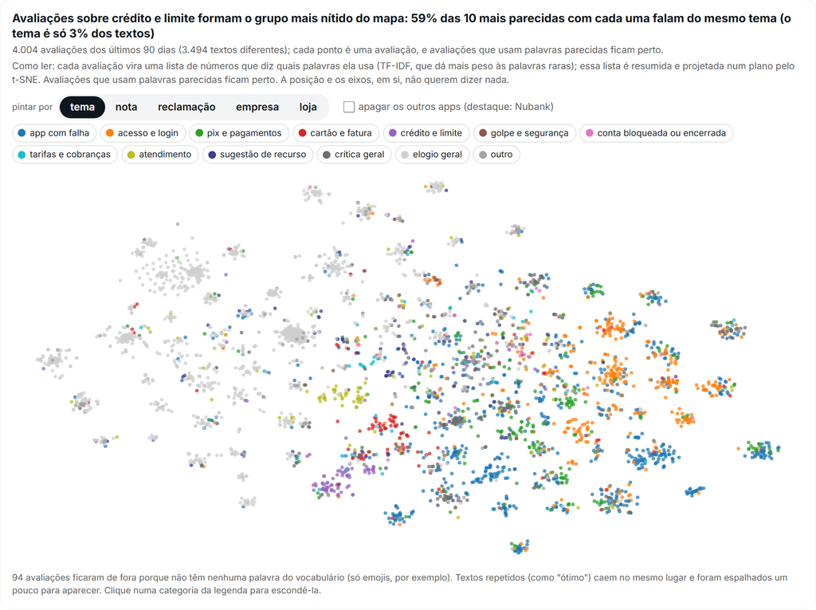

Um modelo dentro do painel, recalculado a cada atualização, sem chave de API.

**1. Texto vira vetor.** Cada avaliação vira uma lista de números: o peso de cada palavra que ela usa (TF-IDF).

**2. Vetor vira ponto.** O t-SNE projeta esses vetores num plano, mantendo perto o que é parecido.

**3. A cor vem do Jev.** Pinte por tema, nota, reclamação ou app, e veja onde cada assunto se concentra. Passe o mouse para ler a avaliação.

## Regressão da nota por tema

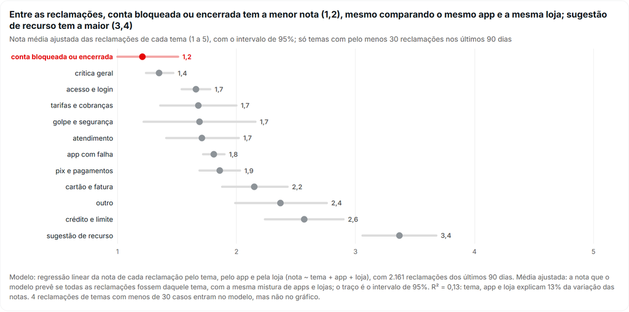

Entre as avaliações que reclamam: **que tema puxa mais a nota para baixo?**

Uma **regressão linear**: a nota explicada pelo tema, pelo app e pela loja. Assim, comparamos temas dentro do mesmo app e da mesma loja.

Cada ponto é a nota média prevista para o tema, com o intervalo de 95%. As colunas que o Jev criou viram variáveis de um modelo, como qualquer outra.

## Painel de exemplo

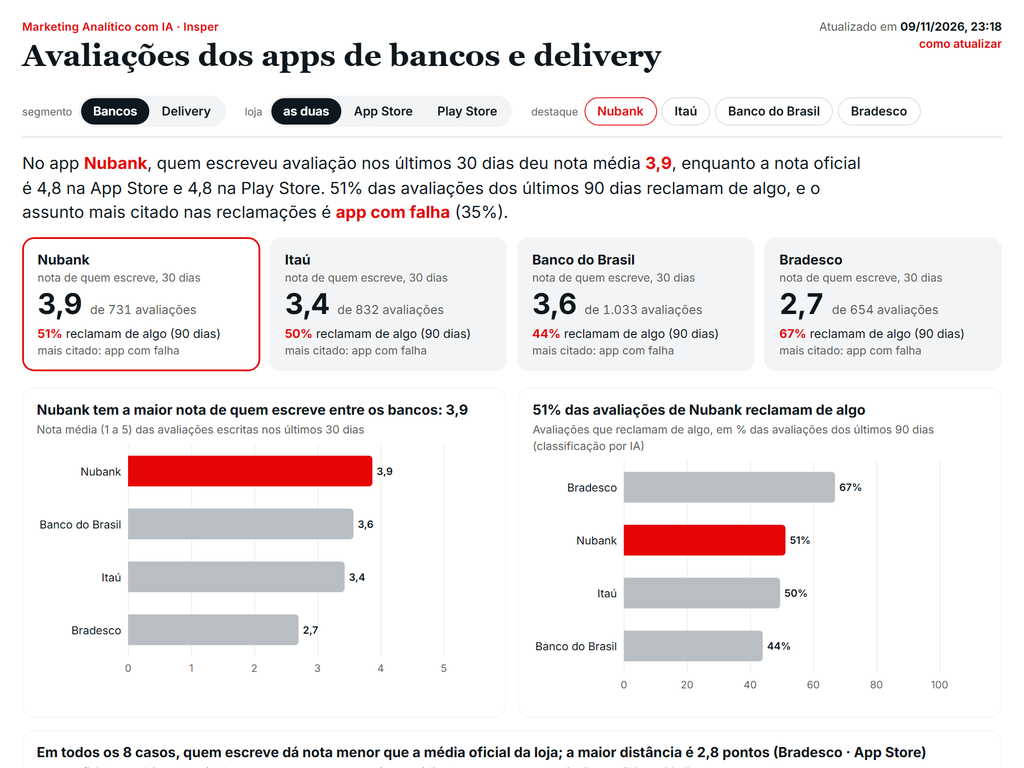

**O painel** [jtrecenti.github.io/avaliacoes-apps/painel](https://jtrecenti.github.io/avaliacoes-apps/painel/)

**O botão de atualizar** [Actions → Atualizar painel → Run workflow](https://github.com/jtrecenti/avaliacoes-apps/actions)

**O código** github.com/jtrecenti/avaliacoes-apps

Vamos apertar o botão agora. Em poucos minutos, a coleta de hoje entra no painel, com as checagens no fim da página.

## Pergunta 5

## Pedido para montar o painel

## Placar final

## Resumo da aula

**Habilidades com código.** Peça à IA para escrever o código que conta e baixa, e guarde o código e o passo a passo numa habilidade.

**Coleta de dados da web.** Procure o feed ou o pacote antes de raspar, e desconfie da amostra: quem escreve não é o cliente médio.

**Estruturação de textos.** Um dicionário com lista fechada, um teste em poucas avaliações, e leitura das de confiança baixa.

**Painéis com atualização.** Passos em arquivos, checagens antes dos números, e um robô que roda e publica todo dia.

## Como estes slides foram feitos

Tudo aqui é texto e código aberto, num repositório público.

## Quarto e GSAP

**Quarto + reveal.js**

Cada slide é um título `##` num arquivo de texto (`slides/index.qmd`). O Quarto transforma o arquivo numa apresentação reveal.js: uma página HTML só, que abre em qualquer navegador.

```
## Temas das reclamações por aplicativo

::: {.cena data-cena="ap-temas"}
:::

[]{.fragment .passo}
```

**GSAP para as animações**

Cada `[]{.fragment .passo}` é um passo. Um pequeno motor conta quantos passos estão visíveis e redesenha a cena a partir desse número, com o GSAP. Voltar um slide nunca deixa a animação pela metade.

Os gráficos das cenas são SVG desenhado em JavaScript, com os números que um script em Python escreve a partir dos dados reais.

## Ferramentas e links

**Os slides** [Quarto](https://quarto.org/docs/presentations/revealjs/), [reveal.js](https://revealjs.com) e [GSAP](https://gsap.com). Escritos junto com um agente de IA (Claude Code), a partir dos materiais do curso de executivos.

**O quiz** Uma página estática que conversa com o [Firebase Realtime Database](https://firebase.google.com/docs/database/rest/start): o celular grava a resposta, o banco carimba a hora, o telão calcula os pontos.

**O painel** [ECharts](https://echarts.apache.org), [scikit-learn](https://scikit-learn.org) (TF-IDF e t-SNE) e [statsmodels](https://www.statsmodels.org), atualizado pelo [GitHub Actions](https://docs.github.com/actions) e publicado no [GitHub Pages](https://pages.github.com).

[figure not shown]

**Tudo está em** github.com/jtrecenti/avaliacoes-apps: os slides, o quiz, a habilidade, o monitor, as checagens e o painel.

**As demonstrações** (pedidos prontos, a entrevista, a habilidade de contagem e os dados): demos.zip. Para a demonstração 4, crie um `.env` com a sua `JEV_API_KEY`.

## Marketing Analítico com IA

[figure not shown]

Obrigado!

Slides, quiz, habilidade, monitor e painel: github.com/jtrecenti/avaliacoes-apps

Julio Trecenti